# CITS4009 Project 2 — Modelling

Shuyu XIE

24112813

> **Notice:**

> This file was generated using an R notebook and saved as a static HTML file, which is hosted on GitHub (https://shuyux.github.io/project/CITS4009_Project_2/). To facilitate access when RStudio is not installed, a shiny application has been uploaded to shinyapps.io (https://jenniferxie.shinyapps.io/CITS2/) and embedded in the static HTML file using an iframe and link format.

> I also submitted an introduction and use tutorial in YouTube (https://youtu.be/wIwpHLU3g68?si=PN-5fX-fc9rZab5f).

# Introduction

The advent of online video consumption has revolutionized content accessibility and engagement. YouTube, as a leading video-sharing platform, has achieved global prominence and garnered billions of users. It offers a wide array of content genres, ranging from entertainment to education and marketing. Understanding the trends and patterns within YouTube’s ecosystem is essential for content creators, marketers, and researchers. This report aims to explore the [“Global YouTube Statistics 2023”](https://www.kaggle.com/datasets/nelgiriyewithana/global-youtube-statistics-2023) dataset available on Kaggle. This comprehensive dataset presents a holistic view of YouTube’s global performance, including metrics such as video views, subscriber counts, channel categories, and regional statistics. By analyzing this dataset, we seek to unearth insights into the current YouTube landscape and uncover trends to drive strategic decision-making and content creation.

## Loading Libraries

```r
library(tidyverse)
library(patchwork)
library(lubridate)
library(caret)
library(pROC)
library(rpart)
library(rpart.plot)
Sys.setlocale(local = "EN")
```

```
[1] "LC_COLLATE=EN;LC_CTYPE=EN;LC_MONETARY=EN;LC_NUMERIC=C;LC_TIME=EN"
```

# Section 1: Preparing Data

## Reading Raw Data

```r
## reading file
DataRaw <- read.csv('./Global YouTube Statistics.csv')
```

## Cleaning Data (as same as Project 1)

```r
## clean date column
DataClean <- DataRaw |>
  ## create date, format is 2023-Jan-1
  mutate(
    Youtuber = str_remove_all(Youtuber, "[^[:alnum:]]"),
    date = paste(created_year, created_month, created_date, sep = "-"),
    date = as.Date(date, format = "%Y-%b-%d")
  ) |>
  select(-c(created_year, created_month, created_date))
DataClean$date[DataClean$date == as.Date("1970-01-01")] <- NA

## replace all nan with NA
NameList <- names(DataClean[,-2])
for (name in NameList) {
  Col <- DataClean[,name]
  if(is.numeric(Col)|class(Col) == "Date"){
    DataClean[is.nan(DataClean[,name]),name] <- NA
  } else {
    DataClean[DataClean[,name] == "nan",name] <- NA
  }
}

## Replace na with 0 in `video_views_for_the_last_30_days` and `subscribers_for_last_30_days`
DataClean$video_views_for_the_last_30_days[is.na(DataClean$video_views_for_the_last_30_days)] <- 0
DataClean$subscribers_for_last_30_days[is.na(DataClean$subscribers_for_last_30_days)] <- 0

## Replace na with "Unavailable" in `category` and `channel_type`
DataClean$category[is.na(DataClean$category)] <- "Unavailable"
DataClean$channel_type[is.na(DataClean$channel_type)] <- "Unavailabe"

## Correct na and unusual value with real data from YouTube
DataClean$date[DataClean$Youtuber == "ChrisBrown"] <- as.Date("2006-12-21")
DataClean$date[DataClean$Youtuber == "GoodMythicalMorning"] <- as.Date("2008-9-17")
DataClean$date[DataClean$Youtuber == "TheGameTheorists"] <- as.Date("2009-08-23")
DataClean$date[DataClean$Youtuber == "LEGENDAFUNK"] <- as.Date("2013-05-11")
DataClean$date[DataClean$Youtuber == "HarryStyles"] <- as.Date("2017-3-9")
DataClean$date[DataClean$Youtuber == "ChrisBrown"] <- as.Date("2006-12-21")
DataClean$date[DataClean$Youtuber == "YouTube"] <- as.Date("2005-02-14")

## Convert date to age
DataClean$age <- as.numeric((as.Date('2023-01-01') - DataClean$date)/365.25)
```

## Aggregating data

This section is dedicated to preparing the data for analysis. Initially, I will prune unnecessary columns to streamline our dataset. Subsequently, I will eliminate observations where country information is missing to ensure data integrity. As a final step, a new column will be introduced to categorize higher-earning YouTubers.

It’s worth noting that, in adjusting for social and economic factors’ impact on income, I’ve chosen not to rely on traditional metrics such as GDP or GDP per capita. Instead, I’ve opted for the “Proportion of Population Covered by at Least a 4G Mobile Network,” a metric provided by Our World in Data (https://ourworldindata.org/grapher/share-with-4g-mobile-network-coverage?tab=chart). This choice is grounded in the belief that this indicator may be more pertinent than GDP. The rationale lies in the idea that the accessibility and prevalence of a 4G mobile network could offer a more nuanced perspective on the technological landscape and its potential influence on income.

```r
DataClean <- DataClean |>
  ## discard unless columns
  select(-c(Title, rank, date)) |>
  ## drop country is missing
  filter(!is.na(Country))
Data4G <- read.csv('./share-with-4g-mobile-network-coverage.csv') |>
  filter(Year == 2021)
Data4G <- Data4G[,c(1, 4)]
names(Data4G) <- c('Country', 'share')

# join dataset
DataClean <- DataClean |>
  left_join(Data4G, by = 'Country')
DataClean$share[DataClean$Country == 'Philippines'] <- 80

## add new column to tag the higher earning
DataClean <- DataClean|>
  mutate(sharegroup = cut(share,
                          breaks = c(0, 99, 99.5, 99.8, 100))
         ) |>
  group_by(sharegroup) |>
  mutate(
    BoundEarn = quantile(highest_monthly_earnings, 0.5),
    TopEarn = if_else(highest_monthly_earnings >= BoundEarn,
                      1,
                      0)
  ) |>
  ungroup()
round(100 *table(DataClean$TopEarn)/nrow(DataClean), 4)
```

```
      0       1
49.8282 50.1718
```

50.172% of the observations are tagged as higher earning YouTubers. This is a high percentage, considering that there should only about 50.00% observations tagged as the higher earning YouTubers. This may be due to some YouTubers having nearly the same highest monthly earnings.

Next, I will proceed to choose the columns essential for our analysis while eliminating variables that exhibit strong correlations with the target variable. Notably, I will exclude columns like `highest_monthly_earnings` and `highest_yearly_earning` due to their high correlation with the target. Additionally, I will remove certain rank-related variables from the dataset, such as `channel_type_rank` and `country_rank`.

Furthermore, considering the exceptionally strong correlation between `video_views_for_the_last_30_days` and `video.views`, I have opted to retain only video.views to avoid multicollinearity issues. As for `Abbreviation`, `Longitude`, and `Latitude`, these variables have been removed from the dataset due to their lack of relevance to our current analysis. Moreover, the variable `channel_type` has also been removed from the dataset as its redundancy with category was leading to an excessively high level of duplication.

```r
DataClean <- DataClean |>
  select(-c(uploads, channel_type, Youtuber,
            share, sharegroup, BoundEarn,
            Abbreviation, Longitude, Latitude, Country,
            video_views_rank, country_rank, channel_type_rank,
            video_views_for_the_last_30_days, subscribers_for_last_30_days,
            highest_monthly_earnings, highest_yearly_earnings,
            lowest_monthly_earnings, lowest_yearly_earnings))
DataClean <- DataClean |>
  mutate(
    na_count = rowSums(is.na(DataClean))
  )
table(DataClean$na_count)
```

```
  0   4
872   1
```

‘Andorra’ seems to lack country-specific information, and I was unable to find any relevant data in the World Bank database. Therefore, we will have to exclude this particular observation in the upcoming analysis.

```r
DataClean <- DataClean[DataClean$na_count == 0,]
DataClean <- DataClean |>
  select(-na_count)
table(DataClean$TopEarn)
```

```
  0   1
434 438
```

```r
round(100 * table(DataClean$TopEarn)/nrow(DataClean), 4)
```

```
      0       1
49.7706 50.2294
```

A total of 872 observations were included in the study, out of which 438 were classified as “higher-earning YouTubers”, accounting for 50.229% of the total.

## Sub-setting Data

```r
set.seed(20231011)
train_index <- runif(nrow(DataClean)) < 0.8

DataTrain <- DataClean[train_index,]
DataTest <- DataClean[!train_index,]
DataClean$train <- as.numeric(train_index)
```

I split the data into training and testing sets. The training set will be used to train the models, while the testing set will be used to evaluate the models.

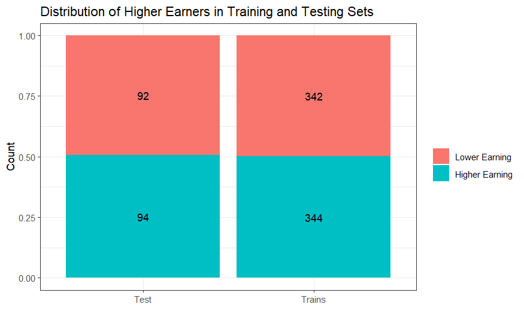

```r
DataClean |>
  ggplot(aes(x = factor(train, levels = 0:1, labels = c('Test', 'Trains')),
             fill = factor(TopEarn, levels = 0:1, labels = c('Lower Earning', 'Higher Earning')))) +
  geom_bar(position = 'fill') +
  geom_text(
    aes(label = after_stat(count), y = after_stat(count) - 0.5),
    stat = 'count',
    position = position_fill(vjust = 0.5)
  ) +
  labs(
    title = "Distribution of Higher Earners in Training and Testing Sets",
    y = "Count",
    x = "",
    fill = ""
  ) +
  theme_bw()
```

In training dataset, there are 344 observations tagged as the higher earning YouTuber, which is 50.146% of the total observations (686). In testing dataset, there are 94 observations tagged as the higher earning YouTuber, which is 50.538% of the total observations (186). The distribution of higher earners in training and testing sets are similar.

# Section 2: Classification

## LIME

```r
DataTrainLIME <- DataTrain
DataTestLIME <- DataTest

model <- glm(
  TopEarn ~ .,
  data = select_if(DataTrainLIME, is.numeric),
  family = binomial(link = "logit")
)
summary(model)
```

```
Call:
glm(formula = TopEarn ~ ., family = binomial(link = "logit"),
    data = select_if(DataTrainLIME, is.numeric))

Coefficients:
                                          Estimate Std. Error z value Pr(>|z|)
(Intercept)                             -6.862e-01  4.498e-01  -1.526  0.12707
subscribers                             -2.877e-08  9.769e-09  -2.945  0.00323 **
video.views                              2.212e-10  2.112e-11  10.477  < 2e-16 ***
Gross.tertiary.education.enrollment.... -7.632e-03  6.374e-03  -1.197  0.23113
Population                               1.465e-09  9.501e-10   1.542  0.12310
Unemployment.rate                        8.175e-02  4.100e-02   1.994  0.04620 *
Urban_population                        -4.392e-09  2.817e-09  -1.559  0.11906
age                                     -6.832e-02  2.302e-02  -2.968  0.00300 **
---
Signif. codes:  0 '***' 0.001 '**' 0.01 '*' 0.05 '.' 0.1 ' ' 1

(Dispersion parameter for binomial family taken to be 1)

    Null deviance: 950.99  on 685  degrees of freedom
Residual deviance: 734.05  on 678  degrees of freedom
AIC: 750.05

Number of Fisher Scoring iterations: 6
```

```r
DataTestLIME$pred <- predict(model, newdata=DataTest, type="response") |>
  as.numeric()
DataTestLIME$pred_binary <- ifelse(DataTestLIME$pred > 0.5, 1, 0)
confusionMatrix(factor(DataTestLIME$pred_binary),
                factor(DataTestLIME$TopEarn))
```

```
Confusion Matrix and Statistics

          Reference
Prediction  0  1
         0 74 30
         1 18 64

               Accuracy : 0.7419
                 95% CI : (0.6728, 0.8032)
    No Information Rate : 0.5054
    P-Value [Acc > NIR] : 3.634e-11

                  Kappa : 0.4845

 Mcnemar's Test P-Value : 0.1124

            Sensitivity : 0.8043
            Specificity : 0.6809
         Pos Pred Value : 0.7115
         Neg Pred Value : 0.7805
             Prevalence : 0.4946
         Detection Rate : 0.3978
   Detection Prevalence : 0.5591
      Balanced Accuracy : 0.7426

       'Positive' Class : 0
```

The overall model performance was evaluated using a confusion matrix and derived statistics. The model achieved an accuracy of approximately 74.19%. Sensitivity and specificity were 0.8043 and 0.6809, respectively. We can also examine a few cases in our test set:

```r
set.seed(20231014)
cases <- sample(nrow(DataTestLIME), 10, replace = F)
DataTestLIME[cases, c('TopEarn', 'pred')]
```

| TopEarn | pred |
| --- | --- |
| 0 | 0.3378202 |
| 1 | 0.9933772 |
| 1 | 0.5778923 |
| 0 | 0.6333591 |
| 1 | 0.2403398 |
| 1 | 0.8812624 |
| 0 | 0.5591642 |
| 0 | 0.2923836 |
| 1 | 0.7278562 |
| 0 | 0.2422713 |

Most were right, but some were wrong, the sensitivity and specificity of model is lower than 100%.

## Single Variable Models

### Process the categorical variables

```r
set.seed(20231014)
DataCleanSingleTrainAll <- DataTrain
DataCleanSingleTest <- DataTest

outcome <- 'TopEarn'
pos <- '1'

Vars <- setdiff(colnames(DataCleanSingleTrainAll), c(outcome))
catVars <- Vars[sapply(DataCleanSingleTrainAll[,Vars], class) %in% c('factor','character')]
numericVars <- Vars[sapply(DataCleanSingleTrainAll[,Vars], class) %in% c('numeric','integer')]

useForCal <- rbinom(n=dim(DataCleanSingleTrainAll)[[1]], size=1, prob=0.1) > 0
DataCleanSingleCal <- subset(DataCleanSingleTrainAll, useForCal)
DataCleanSingleTrain <- subset(DataCleanSingleTrainAll,!useForCal)

mkPredC <- function(outCol, varCol, appCol) {
  pPos <- sum(outCol==pos)/length(outCol)
  # browser()
  naTab <- table(as.factor(outCol[is.na(varCol)]))
  pPosWna <- (naTab/sum(naTab))[pos]
  vTab <- table(as.factor(outCol), varCol)
  pPosWv <- (vTab[pos,]+1.0e-3*pPos)/(colSums(vTab)+1.0e-3)
  pred <- pPosWv[appCol]
  pred[is.na(appCol)] <- pPosWna
  pred[is.na(pred)] <- pPos
  pred
}

for (v in catVars) {
  pi <- paste('pred', v, sep='')
  DataCleanSingleTrain[,pi] <- mkPredC(DataCleanSingleTrain[,outcome][[1]],
                                       DataCleanSingleTrain[,v][[1]],
                                       DataCleanSingleTrain[,v][[1]])
  DataCleanSingleCal[,pi] <- mkPredC(DataCleanSingleTrain[,outcome][[1]],
                                     DataCleanSingleTrain[,v][[1]],
                                     DataCleanSingleCal[,v][[1]])
  DataCleanSingleTest[,pi] <- mkPredC(DataCleanSingleTrain[,outcome][[1]],
                                      DataCleanSingleTrain[,v][[1]],
                                      DataCleanSingleTest[,v][[1]])
}
```

### Process the numeric variables

```r
mkPredN <- function(outCol, varCol, appCol) {
  cuts <- unique(as.numeric(
    quantile(varCol, probs=seq(0, 1, 0.1), na.rm=T)))
  varC <- cut(varCol, cuts)
  appC <- cut(appCol, cuts)
  mkPredC(outCol, varC, appC)
}

for (v in numericVars) {
  pi <- paste('pred', v, sep='')
  DataCleanSingleTrain[,pi] <- mkPredC(DataCleanSingleTrain[,outcome][[1]],
                                       DataCleanSingleTrain[,v][[1]],
                                       DataCleanSingleTrain[,v][[1]])
  DataCleanSingleCal[,pi] <- mkPredC(DataCleanSingleTrain[,outcome][[1]],
                                     DataCleanSingleTrain[,v][[1]],
                                     DataCleanSingleCal[,v][[1]])
  DataCleanSingleTest[,pi] <- mkPredC(DataCleanSingleTrain[,outcome][[1]],
                                      DataCleanSingleTrain[,v][[1]],
                                      DataCleanSingleTest[,v][[1]])
}
```

### Compute the log likelihood

```r
logLikelihood <- function(ypred, ytrue) {
  sum(ifelse(ytrue, log(ypred), log(1-ypred)), na.rm=T)
}
```

### Null model

```r
logNull <- logLikelihood(sum(DataCleanSingleCal[,outcome]==pos)/nrow(DataCleanSingleCal),
                         DataCleanSingleCal[,outcome]==pos)
cat("The log likelihood of the Null model is:", logNull)
```

```
The log likelihood of the Null model is: -58.77037
```

The Null model serves as a baseline model used for comparing the performance of more complex models. This log likelihood value provides a baseline for comparing the performance of other models. A higher log likelihood value indicates a better model fit. Therefore, by comparing the log likelihood of other models to the log likelihood of the Null model, you can assess the relative performance of these models compared to the baseline.

### Select best model

```r
selCatVars <- c()
minDrop <- 0

for (v in catVars) {
  pi <- paste('pred', v, sep='')
  devDrop <- 2*(logLikelihood(DataCleanSingleCal[,pi][[1]],
                              DataCleanSingleCal[,outcome]==pos) - logNull)
  if (devDrop >= minDrop) {
    cat(sprintf("%6s, deviance reduction: %g\n", v, devDrop))
    selCatVars <- c(selCatVars, pi)
  } else {
    cat(sprintf("%6s, deviance reduction: %g(DROP)\n", v, devDrop))
  }
}
```

```
category, deviance reduction: -20.8276(DROP)
```

```r
for (v in numericVars) {
  pi <- paste('pred', v, sep='')
  devDrop <- 2*(logLikelihood(DataCleanSingleCal[,pi][[1]],
                              DataCleanSingleCal[,outcome]==pos) - logNull)
  if (devDrop >= minDrop) {
    cat(sprintf("%6s, deviance reduction: %g\n", v, devDrop))
    selNumVars <- c(selNumVars, pi)
  } else {
    cat(sprintf("%6s, deviance reduction: %g(DROP)\n", v, devDrop))
  }
}
```

```
subscribers, deviance reduction: -0.346323(DROP)
video.views, deviance reduction: -0.346323(DROP)
Gross.tertiary.education.enrollment...., deviance reduction: -117.929(DROP)
Population, deviance reduction: -0.346323(DROP)
Unemployment.rate, deviance reduction: -336.583(DROP)
Urban_population, deviance reduction: -0.346323(DROP)
   age, deviance reduction: -490.657(DROP)
```

```r
for (v in Vars) {
  # Calculate roc
  roc_outcome <- roc(DataCleanSingleCal$TopEarn, DataCleanSingleCal[[paste0('pred', v)]])
  # find the area under the curve
  auc_outcome <- auc(roc_outcome)
  cat(v, ": ", auc_outcome, '\n')
}
```

```
subscribers :  0.5
video.views :  0.5
category :  0.5255556
Gross.tertiary.education.enrollment.... :  0.5166667
Population :  0.5
Unemployment.rate :  0.4947222
Urban_population :  0.5
age :  0.5277778
```

Unfortunately, none of the single-variate models were selected, it means that, for this specific dataset and modeling approach, none of the variables provide a significant improvement in model fit when considered in isolation. In other words, the code did not find any single-variable models that substantially improved the model’s performance compared to the Null model.

However, it’s essential to note that this lack of selection does not necessarily imply that these variables are unimportant. There are a few potential reasons for this result. One possibility is that their influence on the target variable is only discernible when they are considered in conjunction with other variables or within a more complex model.

For instance, consider the variables `subscribers`, `video.views`, `Population`, and `Urban_population`. Their deviance reduction values are nearly zero, indicating that, when considered separately, they don’t significantly contribute to the model’s predictive power. What’s even more intriguing is that the deviance reduction values for the single-variable models of these four variables are identical. This suggests that, for these specific variables, there might be some multicollinearity or complex interactions at play. Multicollinearity can occur when predictor variables are highly correlated with each other, making it challenging to tease apart their individual effects on the target variable. As a result, their contributions become less discernible in single-variable models. In such cases, it becomes crucial to explore how these variables interact with each other within a more comprehensive model to capture their combined and potentially significant impact on the target variable.

## decision Tree Classifier

### Build Models

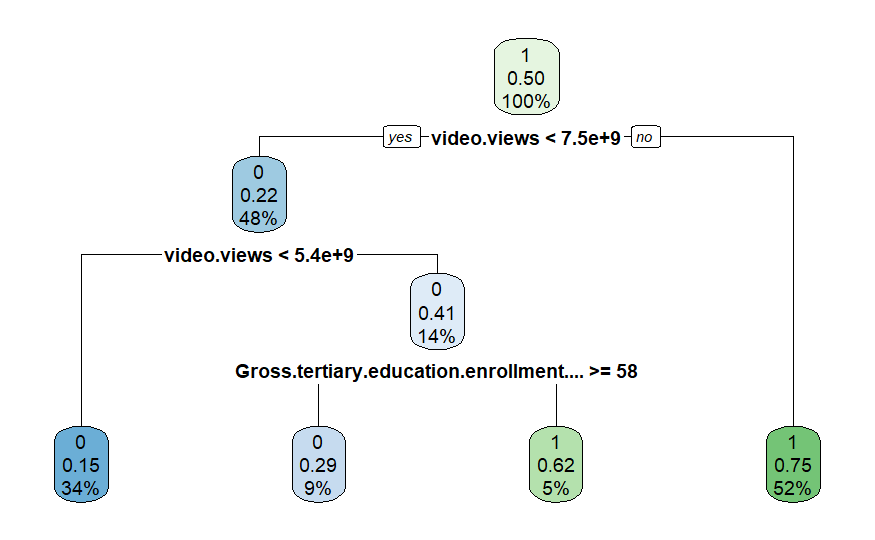

```r
model_dt <- rpart(
  as.factor(TopEarn) ~ .,
  data = DataTrain |> select(-category)
)
rpart.plot(model_dt)
```

```r
outcome_dt <- predict(model_dt, DataTest, type = 'class')
roc_dt <- roc(DataTest$TopEarn, as.numeric(outcome_dt))
confusionMatrix(outcome_dt, as.factor(DataTest$TopEarn))
```

```
Confusion Matrix and Statistics

          Reference
Prediction  0  1
         0 71 19
         1 21 75

               Accuracy : 0.7849
                 95% CI : (0.7189, 0.8417)
    No Information Rate : 0.5054
    P-Value [Acc > NIR] : 3.478e-15

                  Kappa : 0.5697

 Mcnemar's Test P-Value : 0.8744

            Sensitivity : 0.7717
            Specificity : 0.7979
         Pos Pred Value : 0.7889
         Neg Pred Value : 0.7812
             Prevalence : 0.4946
         Detection Rate : 0.3817
   Detection Prevalence : 0.4839
      Balanced Accuracy : 0.7848

       'Positive' Class : 0
```

As the confusion matrix shows, the model achieved an accuracy of approximately 78.49%. Sensitivity and specificity were 0.772 and 0.798, respectively.

## Logistic Regression Classifier

### Build Models

```r
DataTrainLog <- DataTrain |>
  select(-category)
DataTestLog <- DataTrain |>
  select(-category)

model_log <- glm(
  TopEarn ~ .,
  data = DataTrainLog,
  family = binomial(link = "logit")
)
summary(model_log)
```

```
Call:
glm(formula = TopEarn ~ ., family = binomial(link = "logit"),
    data = DataTrainLog)

Coefficients:
                                          Estimate Std. Error z value Pr(>|z|)
(Intercept)                             -6.862e-01  4.498e-01  -1.526  0.12707
subscribers                             -2.877e-08  9.769e-09  -2.945  0.00323 **
video.views                              2.212e-10  2.112e-11  10.477  < 2e-16 ***
Gross.tertiary.education.enrollment.... -7.632e-03  6.374e-03  -1.197  0.23113
Population                               1.465e-09  9.501e-10   1.542  0.12310
Unemployment.rate                        8.175e-02  4.100e-02   1.994  0.04620 *
Urban_population                        -4.392e-09  2.817e-09  -1.559  0.11906
age                                     -6.832e-02  2.302e-02  -2.968  0.00300 **
---
Signif. codes:  0 '***' 0.001 '**' 0.01 '*' 0.05 '.' 0.1 ' ' 1

(Dispersion parameter for binomial family taken to be 1)

    Null deviance: 950.99  on 685  degrees of freedom
Residual deviance: 734.05  on 678  degrees of freedom
AIC: 750.05

Number of Fisher Scoring iterations: 6
```

The intercept term is estimated to be -0.6862, indicating the log-odds of the outcome variable when all other predictors are zero. The “video.views” predictor has a positive coefficient estimate of 2.212e-10 (P<0.001), indicating that a one-unit increase in video views is associated with an increase in the log-odds of the outcome. The “subscribers” predictor has a coefficient estimate of -2.877e-08 (P=0.003), suggesting that a one-unit increase in subscribers is associated with a decrease in the log-odds of the outcome. This seems unreasonable, as it suggests that an increase in subscribers is negatively related to the outcome variable. However, it is important to note that the magnitude of the coefficient estimate is very small, which suggests that the effect size of “subscribers” on the outcome variable may be negligible.

It is also important to consider other factors that may be influencing the relationship between “subscribers” and the outcome variable. For example, it is possible that the quality of the content being produced is more important than the number of subscribers in predicting the outcome variable. Additionally, there may be confounding variables that are not included in the model that are influencing the relationship between “subscribers” and the outcome variable.

```r
DataTrain |>
  select(-TopEarn) |>
  select_if(is.numeric) |>
  cor() |>
  round(2)
```

```
                                        subscribers video.views
subscribers                                    1.00        0.78
video.views                                    0.78        1.00
Gross.tertiary.education.enrollment....       -0.03       -0.04
Population                                     0.10        0.10
Unemployment.rate                             -0.01        0.00
Urban_population                               0.11        0.10
age                                            0.15        0.15
                                        Gross.tertiary.education.enrollment.... Population
subscribers                                                               -0.03       0.10
video.views                                                               -0.04       0.10
Gross.tertiary.education.enrollment....                                    1.00      -0.60
Population                                                                -0.60       1.00
Unemployment.rate                                                          0.68      -0.23
Urban_population                                                          -0.32       0.91
age                                                                        0.17      -0.14
                                        Unemployment.rate Urban_population   age
subscribers                                         -0.01             0.11  0.15
video.views                                          0.00             0.10  0.15
Gross.tertiary.education.enrollment....              0.68            -0.32  0.17
Population                                          -0.23             0.91 -0.14
Unemployment.rate                                    1.00             0.14  0.14
Urban_population                                     0.14             1.00 -0.09
age                                                  0.14            -0.09  1.00
```

Based on the EDA results and the coefficient estimates from the logistic regression models, it is clear that both “subscribers” and “video.views” are important predictors of the outcome variable, “TopEarn.” However, as mentioned earlier, the high correlation between these two predictors could potentially lead to confounding effects. To further investigate the individual and combined effects of these predictors, we can build additional models that include both predictors. One approach is to use regularization techniques such as ridge regression or lasso regression, which can help to reduce the impact of multicollinearity and improve the stability of the coefficient estimates.

Another approach is to use interaction terms, which can capture the joint effects of “subscribers” and “video.views” on the outcome variable. For example, we could include a term for the product of “subscribers” and “video.views” in the model:

```r
model_log_j <- glm(
  TopEarn ~ . + subscribers * video.views,
  data = DataTrainLog,
  family = binomial(link = "logit")
)
summary(model_log_j)
```

```
Call:
glm(formula = TopEarn ~ . + subscribers * video.views, family = binomial(link = "logit"),
    data = DataTrainLog)

Coefficients:
                                          Estimate Std. Error    z value Pr(>|z|)
(Intercept)                             -2.587e+15  1.253e+07 -206455824   <2e-16 ***
subscribers                              3.402e+06  2.258e-01   15068718   <2e-16 ***
video.views                              1.409e+05  3.634e-04  387642240   <2e-16 ***
Gross.tertiary.education.enrollment....  1.848e+13  1.739e+05  106250917   <2e-16 ***
Population                               4.714e+06  2.766e-02  170403856   <2e-16 ***
Unemployment.rate                        1.073e+14  1.127e+06   95285161   <2e-16 ***
Urban_population                        -1.546e+07  8.115e-02 -190508727   <2e-16 ***
age                                     -7.073e+12  6.372e+05  -11099884   <2e-16 ***
subscribers:video.views                 -5.415e-04  2.013e-12 -268953230   <2e-16 ***
---
Signif. codes:  0 '***' 0.001 '**' 0.01 '*' 0.05 '.' 0.1 ' ' 1

(Dispersion parameter for binomial family taken to be 1)

    Null deviance:   950.99  on 685  degrees of freedom
Residual deviance: 18310.18  on 677  degrees of freedom
AIC: 18328

Number of Fisher Scoring iterations: 15
```

```r
model_log_s <- glm(
  TopEarn ~ .,
  data = select(DataTrainLog, -subscribers),
  family = binomial(link = "logit")
)
summary(model_log_s)
```

```
Call:
glm(formula = TopEarn ~ ., family = binomial(link = "logit"),
    data = select(DataTrainLog, -subscribers))

Coefficients:
                                          Estimate Std. Error z value Pr(>|z|)
(Intercept)                             -1.026e+00  4.337e-01  -2.365  0.01803 *
video.views                              1.949e-10  1.832e-11  10.637  < 2e-16 ***
Gross.tertiary.education.enrollment.... -7.365e-03  6.315e-03  -1.166  0.24348
Population                               1.543e-09  9.434e-10   1.636  0.10184
Unemployment.rate                        8.352e-02  4.071e-02   2.051  0.04022 *
Urban_population                        -4.667e-09  2.797e-09  -1.669  0.09516 .
age                                     -6.893e-02  2.282e-02  -3.021  0.00252 **
---
Signif. codes:  0 '***' 0.001 '**' 0.01 '*' 0.05 '.' 0.1 ' ' 1

(Dispersion parameter for binomial family taken to be 1)

    Null deviance: 950.99  on 685  degrees of freedom
Residual deviance: 741.84  on 679  degrees of freedom
AIC: 755.84

Number of Fisher Scoring iterations: 6
```

```r
model_log_v <- glm(
  TopEarn ~ .,
  data = select(DataTrainLog, -video.views),
  family = binomial(link = "logit")
)
summary(model_log_v)
```

```
Call:
glm(formula = TopEarn ~ ., family = binomial(link = "logit"),
    data = select(DataTrainLog, -video.views))

Coefficients:
                                          Estimate Std. Error z value Pr(>|z|)
(Intercept)                             -5.482e-01  3.919e-01  -1.399   0.1618
subscribers                              3.757e-08  7.929e-09   4.739 2.15e-06 ***
Gross.tertiary.education.enrollment.... -4.199e-03  5.347e-03  -0.785   0.4323
Population                               1.278e-09  8.436e-10   1.515   0.1297
Unemployment.rate                        6.686e-02  3.474e-02   1.925   0.0542 .
Urban_population                        -3.614e-09  2.475e-09  -1.460   0.1442
age                                     -3.551e-02  1.964e-02  -1.808   0.0706 .
---
Signif. codes:  0 '***' 0.001 '**' 0.01 '*' 0.05 '.' 0.1 ' ' 1

(Dispersion parameter for binomial family taken to be 1)

    Null deviance: 950.99  on 685  degrees of freedom
Residual deviance: 908.42  on 679  degrees of freedom
AIC: 922.42

Number of Fisher Scoring iterations: 5
```

Moving on to the model that excludes `subscribers`, the coefficient estimate for `video.views` is statistically significant at the 0.05 level, suggesting that it is an important predictor of `TopEarn`. However, this model does not capture the potential joint effects of `subscribers` and `video.views` on the outcome variable. Similarly, the model that excludes `video.views` has a statistically significant coefficient estimate for `subscribers`, but does not capture the potential joint effects of the two predictors.

### Compare Models

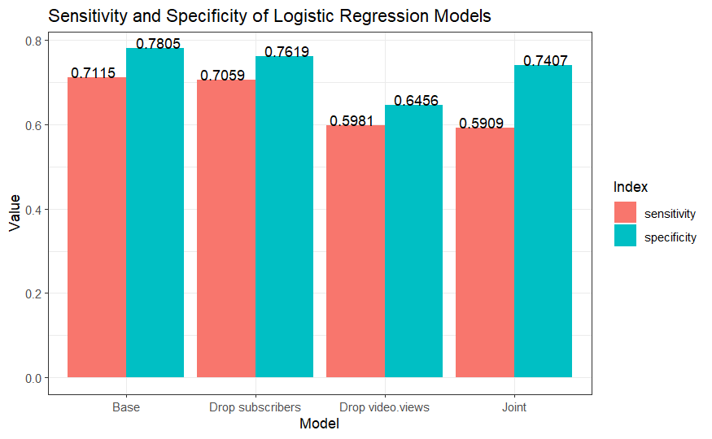

```r
calculate_index <- function(model, data, threshold = 0.5) {
  # Make predictions
  predictions <- predict(model, newdata = data, type = "response")

  # Convert to binary classification
  predictions_binary <- ifelse(predictions > threshold, 1, 0)

  # Calculate confusion matrix
  actual <- data$TopEarn
  confusion_matrix <- confusionMatrix(as.factor(actual), as.factor(predictions_binary))
  sensitivity <- confusion_matrix$byClass[1]
  specificity <- confusion_matrix$byClass[2]

  # Return sensitivity and specificity
  return(list(sensitivity = sensitivity, specificity = specificity))
}

index_log = calculate_index(model = model_log, data = DataTest)
index_log_j = calculate_index(model = model_log_j, data = DataTest)
index_log_s = calculate_index(model = model_log_s, data = DataTest)
index_log_v = calculate_index(model = model_log_v, data = DataTest)

## convert to dataframe
outcome_log = data.frame(
  model = c('Base', 'Joint', 'Drop subscribers', 'Drop video.views'),
  sensitivity = as.numeric(c(index_log[1], index_log_j[1], index_log_s[1], index_log_v[1])),
  specificity = as.numeric(c(index_log[2], index_log_j[2], index_log_s[2], index_log_v[2]))
)

## plot
outcome_log |>
    pivot_longer(cols = c(sensitivity, specificity), names_to = "index", values_to = "value") |>
    ggplot(aes(x = model, y = value, fill = index)) +
    geom_col(position = "dodge") +
    geom_text(
        aes(label = round(value, 4), y = value),
        position = position_dodge(width = 1),
        vjust = 0
    ) +
    labs(
        title = "Sensitivity and Specificity of Logistic Regression Models",
        x = "Model",
        y = "Value",
        fill = "Index"
    ) +
    theme_bw()
```

```r
predictions <- predict(model_log, newdata = DataTest, type = "response")
roc_data_log <- roc(DataTest$TopEarn, predictions)

predictions <- predict(model_log_j, newdata = DataTest, type = "response")
roc_data_log_j <- roc(DataTest$TopEarn, predictions)

predictions <- predict(model_log_s, newdata = DataTest, type = "response")
roc_data_log_s <- roc(DataTest$TopEarn, predictions)

predictions <- predict(model_log_v, newdata = DataTest, type = "response")
roc_data_log_v <- roc(DataTest$TopEarn, predictions)

par(pty = "s")
plot(roc_data_log, col = "red", main = "ROC Curves for Different Logistic Regression Models")
abline(a = 0, b = 1, lty = 2)
```

```r
lines(roc_data_log_j, col = "blue")
lines(roc_data_log_s, col = "green")
```

[figure not shown]

```r
lines(roc_data_log_v, col = "purple")
legend("bottomright",
       legend = c("Base", "Joint", "Drop subscribers", "Drop video.views"),
       col = c("red", "blue", "green", "purple"), lty = 1)
```

For ROC curves, the model without `subscribers` variable have similar AUC (0.810) with the basic model (0.811). Which means that the `subscribers` variable does not contribute much to the model. However, the model without `video.views` variable have lower AUC (0.680) than the basic model. Which means that the `video.views` variable contribute to the model.

## K nearest neighbor classifier

### Build Models

```r
library(class)

DataTrainScale <- DataTrain |>
  select_if(is.numeric) |>
  select(-TopEarn) |>
  scale()
DataTestScale <- DataTest |>
  select_if(is.numeric) |>
  select(-TopEarn) |>
  scale()
```

### Compare Models

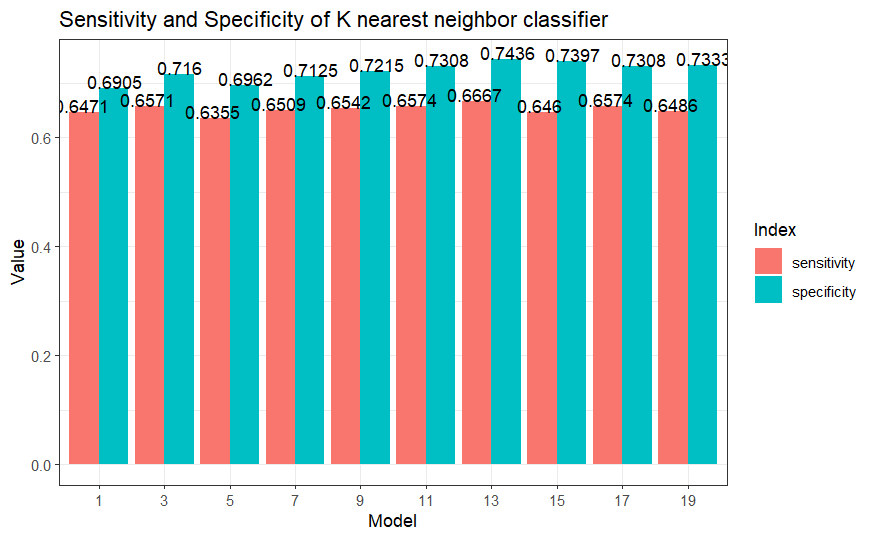

```r
outcome_knn <- data.frame(
  k = numeric(),
  sensitivity = numeric(),
  specificity = numeric()
)

for (k in seq(1,20,2)) {
  model_knn <- knn(
    train = DataTrainScale,
    test = DataTestScale,
    cl = drop_na(DataTrain)$TopEarn,
    k = k
  )

  # build confusion matrix
  confusion_matrix <- confusionMatrix(as.factor(DataTest$TopEarn), as.factor(model_knn))
  sensitivity <- confusion_matrix$byClass[1]
  specificity <- confusion_matrix$byClass[2]

  outcome_knn <- rbind(
    outcome_knn,
    data.frame(
      k = k,
      sensitivity = sensitivity,
      specificity = specificity
    )
  )
}

## plot
outcome_knn |>
    pivot_longer(cols = c(sensitivity, specificity), names_to = "index", values_to = "value") |>
    ggplot(aes(x = as.factor(k), y = value, fill = index)) +
    geom_col(position = "dodge") +
    geom_text(
        aes(label = round(value, 4), y = value),
        position = position_dodge(width = 1),
        vjust = 0
    ) +
    labs(
        title = "Sensitivity and Specificity of K nearest neighbor classifier",
        x = "Model",
        y = "Value",
        fill = "Index"
    ) +
    theme_bw()
```

```r
model_knn <- knn(
    train = DataTrainScale,
    test = DataTestScale,
    cl = drop_na(DataTrain)$TopEarn,
    k = 13
  )
roc_knn <- roc(DataTest$TopEarn, as.integer(model_knn))
```

## Disscussion

```r
par(pty = "s")
plot(roc_dt, col = "red", main = "ROC Curves for Different Models")
abline(a = 0, b = 1, lty = 2)
```

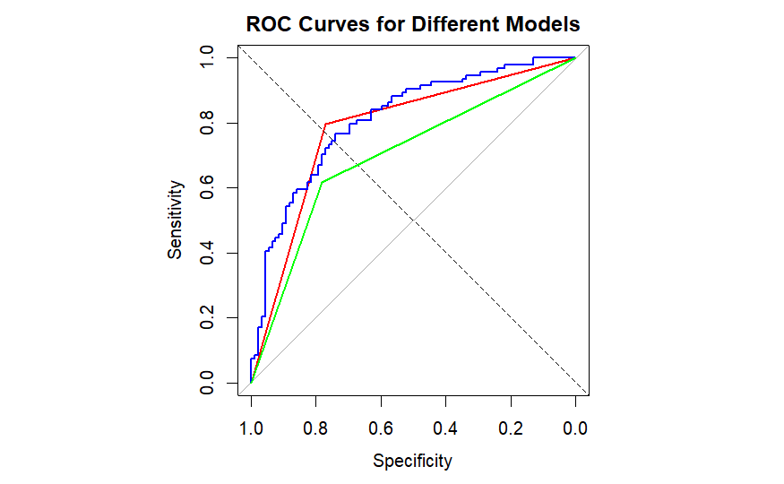

```r
lines(roc_data_log_s, col = "blue")
lines(roc_knn, col = "green")
```

All in all, the logistic regression classifier without `subscribers` variable (blue line) have better performance than the decision tree classifier (red line) and the K nearest neighbor classifier (green line). This can be seen from the ROC curves and the sensitivity and specificity of the models.

# Section 3: Clustering

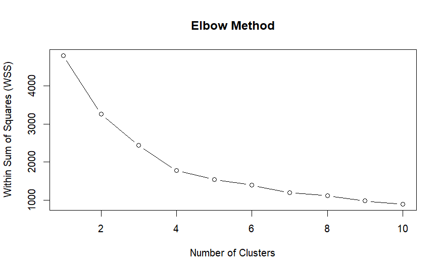

```r
library(cluster)
DataTrainScale <- DataTrain |>
  select_if(is.numeric) |>
  select(-TopEarn) |>
  scale()

# Elbow Method
wss <- numeric(10)
for (i in 1:10) {
  kmeans_temp <- kmeans(DataTrainScale, centers = i, nstart = 10)
  wss[i] <- sum(kmeans_temp$tot.withinss)
}
plot(1:10,
     wss,
     type = "b",
     xlab = "Number of Clusters",
     ylab = "Within Sum of Squares (WSS)",
     main = "Elbow Method")
```

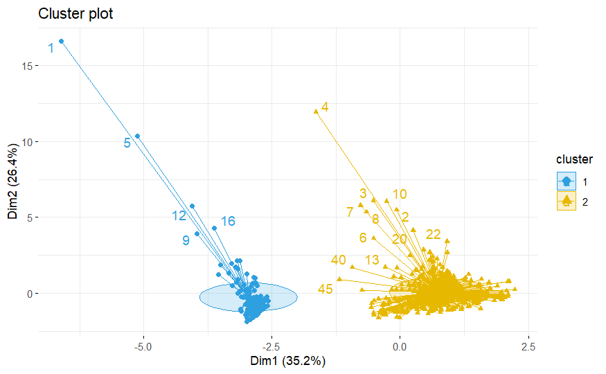

```r
set.seed(20231015)
km <- kmeans(DataTrainScale, 2)

factoextra::fviz_cluster(km, data = DataTrainScale,
             palette = c("#2E9FDF", "#E7B800"),
             ellipse.type = "euclid",
             star.plot = TRUE,
             repel = TRUE,
             ggtheme = theme_minimal()
)
```

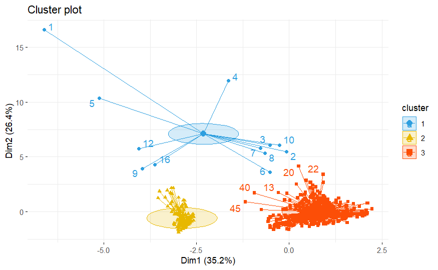

```r
set.seed(20231015)
km <- kmeans(DataTrainScale, 3)
factoextra::fviz_cluster(km, data = DataTrainScale,
             palette = c("#2E9FDF", "#E7B800", "#FC4E07"),
             ellipse.type = "euclid",
             star.plot = TRUE,
             repel = TRUE,
             ggtheme = theme_minimal()
)
```

# Interactive Shiny Application

[interactive chart not shown]

> In the event of a failed webpage loading, you may click on [the link](https://jenniferxie.shinyapps.io/CITS2/) to directly navigate to [shinyapps.io](https://www.shinyapps.io/).

> This intercative builded by [shiny](https://shiny.posit.co/), and hosted on [shinyapps.io](https://www.shinyapps.io/).

[video not shown]

> If you are not familiar with the operation of this application, you can refer to this video tutorial. If the youtube video doesn’t load, you can try clicking [the link](https://youtu.be/wIwpHLU3g68?si=PN-5fX-fc9rZab5f).

# Statement

[OpenAI ChatGPT-3.5-turbo](https://chat.openai.com/) Used for Chinese translation to English and language polishing.